# Machine Learning

## Usando Python

El Machine Learning utilizando Python es una combinación poderosa que aprovecha las bibliotecas y herramientas disponibles en el ecosistema de Python para desarrollar y desplegar modelos de aprendizaje automático.

Data (Datos): Comienza con la recopilación de datos relevantes para tu problema. Los datos deben ser limpios, completos y representativos del problema que estás tratando de resolver.

Machine Learning (Aprendizaje Automático): Utilizando librerías de Python como scikit-learn, TensorFlow o PyTorch, puedes elegir el tipo de modelo que mejor se adapte a tu problema (por ejemplo, regresión, clasificación, clustering, etc.).

Librerías a utilizar: Las librerías más populares para Machine Learning en Python incluyen:

scikit-learn: Es una de las librerías más utilizadas para Machine Learning. Ofrece una amplia gama de algoritmos y herramientas para tareas de clasificación, regresión, clustering, etc. TensorFlow y PyTorch: Estas librerías son especialmente populares para el desarrollo de redes neuronales y deep learning.

Preparación de data: Antes de alimentar tus datos al modelo, es importante preprocesarlos. Esto puede implicar la limpieza de datos, normalización, codificación de variables categóricas, manejo de valores faltantes, entre otros.

Gráfica de datos: Puedes utilizar bibliotecas como Matplotlib o Seaborn para visualizar tus datos. La visualización puede ayudar a comprender mejor la relación entre las variables y detectar posibles patrones.

Modelo: Elige el tipo de modelo que mejor se adapte a tu problema. Por ejemplo, si estás haciendo clasificación, podrías usar un clasificador como Random Forest, SVM, etc.

Entrenamiento: Utiliza tu conjunto de datos de entrenamiento para entrenar el modelo. Esto implica ajustar los parámetros del modelo para minimizar el error en las predicciones.

Precisión de validación: Después del entrenamiento, es importante evaluar el rendimiento del modelo en un conjunto de datos que no haya visto antes (conjunto de validación). Puedes utilizar métricas como la precisión, el F1-score, etc., según el tipo de problema que estés abordando.

Pronóstico: Una vez que el modelo está entrenado y validado, puedes utilizarlo para hacer predicciones en nuevos datos.

Error de pronóstico: Evalúa el rendimiento del modelo en los datos de prueba utilizando métricas relevantes. Esto te dará una idea de qué tan bien se generaliza el modelo a datos no vistos.

### Un clasificador SVM (Support Vector Machine)

es un algoritmo de aprendizaje supervisado utilizado para la clasificación y, en algunos casos, para la regresión. Su objetivo principal es encontrar el hiperplano que mejor separa las clases en el espacio de características.

Para entender esto, es útil explicar algunos conceptos clave:

Hiperplano: En un espacio bidimensional, un hiperplano es simplemente una línea que separa dos clases. En un espacio tridimensional, sería un plano, y en espacios de dimensiones superiores, es una generalización de esto.

Vectores de Soporte: Son los puntos más cercanos al hiperplano y tienen una influencia en la posición del hiperplano. Estos son los puntos que, si se cambian o se eliminan, podrían alterar la posición del hiperplano.

Margen: Es la distancia entre el hiperplano y el punto más cercano de cada clase. El objetivo es maximizar este margen, lo que da lugar a un clasificador que generaliza bien para nuevos datos.

El proceso de entrenamiento de un clasificador SVM implica:

Definir el problema de optimización: El objetivo es encontrar el hiperplano que maximice el margen entre las clases y minimice la clasificación errónea.

Optimización: Se resuelve un problema de optimización cuadrática para encontrar el hiperplano óptimo.

Clasificación: Una vez que se ha encontrado el hiperplano, se utiliza para clasificar nuevos datos.

Tipos de SVM: SVM Lineal: Es adecuado para problemas de clasificación linealmente separables, es decir, cuando las clases pueden ser separadas por una línea recta en el espacio de características.

SVM No Lineal (o Kernel SVM): Para casos donde los datos no pueden ser separados linealmente en el espacio de características, se utilizan transformaciones no lineales (kernel tricks) para mapearlos a un espacio de mayor dimensión donde se vuelven linealmente separables.

Ejemplos de kernel: lineal, polinómico, RBF (Radial Basis Function), etc. SVM de Regresión: En lugar de clasificar datos en categorías, este tipo de SVM se utiliza para la regresión, es decir, predecir un valor numérico en lugar de una etiqueta de clase.

Ventajas de SVM: Eficaz en espacios de alta dimensión. Eficaz cuando el número de características es mayor que el número de muestras. Es eficaz en casos donde el número de características es menor que el número de muestras. Limitaciones: Puede ser sensible a la elección del kernel y a la configuración de hiperparámetros. El tiempo de entrenamiento puede ser alto para grandes conjuntos de datos. No es directamente interpretable.

Vamos a crear un ejemplo sencillo de clasificación usando el conjunto de datos Iris, que es un conjunto de datos muy comúnmente utilizado en Machine Learning. Este conjunto de datos contiene medidas de longitud y ancho de sépalos y pétalos de tres especies de flores iris.

## Paso 1: Data (Datos)

Primero, importaremos las librerías necesarias y cargaremos el conjunto de datos Iris.

```python
import pandas as pd
from sklearn.datasets import load_iris

# Cargar el conjunto de datos Iris
iris = load_iris()
X = iris.data
y = iris.target
```

## Paso 2: Machine Learning (Aprendizaje Automático)

Para este ejemplo, utilizaremos un clasificador de Support Vector Machine (SVM) para clasificar las flores en una de las tres especies.

```python
from sklearn.svm import SVC

# Crear el modelo SVM
model = SVC()
```

## Paso 3: Librerías a utilizar

Ya hemos importado las librerías necesarias en los pasos anteriores (pandas y sklearn).

## Paso 4: Preparación de data

No se necesita preprocesamiento adicional para este conjunto de datos. Ya está limpio y listo para ser utilizado.

## Paso 5: Gráfica de datos

Podemos usar gráficos para visualizar los datos, pero dado que el conjunto de datos Iris tiene 4 dimensiones, es difícil visualizarlo completamente. Sin embargo, podemos reducirlo a 2 dimensiones usando PCA para visualizarlo en un gráfico de dispersión.

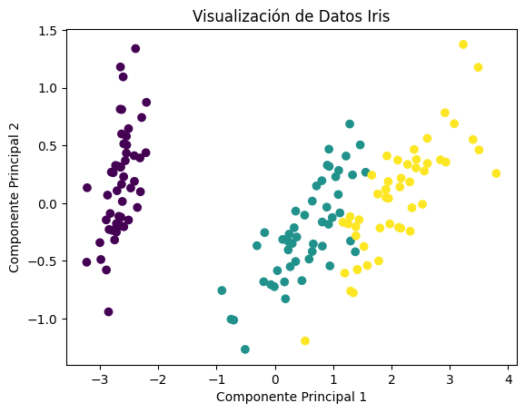

```python
from sklearn.decomposition import PCA
import matplotlib.pyplot as plt

# Reducción de dimensionalidad con PCA
pca = PCA(n_components=2)
X_pca = pca.fit_transform(X)

# Graficar los datos
plt.scatter(X_pca[:, 0], X_pca[:, 1], c=y, cmap='viridis')
plt.xlabel('Componente Principal 1')
plt.ylabel('Componente Principal 2')
plt.title('Visualización de Datos Iris')
plt.show()
```

## Paso 6: Modelo

Ya hemos creado el modelo SVM en el paso 2.

## Paso 7: Entrenamiento

Ahora, dividiremos los datos en un conjunto de entrenamiento y un conjunto de prueba para entrenar el modelo y evaluar su rendimiento.

```python
from sklearn.model_selection import train_test_split

# Dividir los datos en entrenamiento y prueba
X_train, X_test, y_train, y_test = train_test_split(X, y, test_size=0.2, random_state=42)

# Entrenar el modelo
model.fit(X_train, y_train)
```

```
SVC()
```

## Paso 8: Precisión de validación

Vamos a evaluar el rendimiento del modelo en el conjunto de prueba.

```python
from sklearn.metrics import accuracy_score

# Hacer predicciones en el conjunto de prueba
y_pred = model.predict(X_test)

# Calcular la precisión
accuracy = accuracy_score(y_test, y_pred)
print(f'Precisión del modelo: {accuracy*100:.2f}%')
```

```
Precisión del modelo: 100.00%
```

## Paso 9: Pronóstico

Ahora, puedes utilizar el modelo entrenado para hacer predicciones en nuevos datos.

```python
# Ejemplo de predicción con nuevos datos
new_data = [[5.1, 3.5, 1.4, 0.2]]  # Aquí proporciona los valores de sépalo y pétalo
prediction = model.predict(new_data)
print(f'La especie de la flor es: {iris.target_names[prediction][0]}')
```

```
La especie de la flor es: setosa
```

## Paso 10: Error de pronóstico

Para este ejemplo, hemos calculado la precisión en el paso 8, pero dependiendo del problema, podrías utilizar otras métricas de evaluación.

# Conclusiones

Preparación de Datos: En este ejemplo, utilizamos el conjunto de datos Iris que es bastante limpio y no requiere un preprocesamiento extenso. Sin embargo, en proyectos reales, a menudo es necesario realizar pasos de limpieza, normalización y manejo de datos faltantes.

Selección de Modelo: Elegimos un clasificador SVM para este ejemplo. La elección del modelo depende del tipo de problema que estés abordando, la naturaleza de los datos y las características del conjunto de datos.

Visualización de Datos: Utilizamos PCA para reducir la dimensionalidad de los datos y visualizarlos en un gráfico de dispersión. La visualización es una herramienta importante para comprender la distribución de los datos y detectar patrones.

Entrenamiento y Evaluación del Modelo: Dividimos los datos en conjuntos de entrenamiento y prueba, luego entrenamos el modelo y evaluamos su rendimiento en el conjunto de prueba. En proyectos reales, es importante realizar una validación cruzada y ajustar los hiperparámetros para obtener un modelo óptimo.

Predicción de Nuevos Datos: Utilizamos el modelo entrenado para hacer predicciones en nuevos datos. Esto es una parte crucial de cualquier proyecto de Machine Learning ya que el objetivo final es utilizar el modelo para hacer pronósticos en datos no vistos.

Métricas de Evaluación: En este ejemplo, utilizamos la precisión como métrica de evaluación. Sin embargo, dependiendo del problema, otras métricas como la sensibilidad, la especificidad, el F1-score, etc., pueden ser más relevantes.

Flexibilidad de Python: Python es un lenguaje muy flexible y poderoso para el Machine Learning. Tiene una gran cantidad de librerías y herramientas que facilitan el desarrollo de modelos y el análisis de datos.

SVM como Herramienta de Clasificación: Entendimos cómo funciona un clasificador SVM y cómo puede utilizarse para problemas de clasificación. Es especialmente eficaz en espacios de alta dimensión y en casos donde las clases no son linealmente separables.